# Updated Report for Edovo 8-5

Abby Smith

8/5/2020

Data summary

| Name | edovo_user_data |
| --- | --- |
| Number of rows | 288777 |
| Number of columns | 26 |
| _______________________ |  |
| Column type frequency: |  |
| character | 14 |
| Date | 1 |
| numeric | 8 |
| POSIXct | 3 |
| ________________________ |  |
| Group variables | None |

**Variable type: character**

| skim_variable | n_missing | complete_rate | min | max | empty | n_unique | whitespace |
| --- | --- | --- | --- | --- | --- | --- | --- |
| inmate_id | 2 | 1.00 | 1 | 40 | 0 | 260099 | 0 |
| first_name | 11431 | 0.96 | 1 | 31 | 0 | 48663 | 0 |
| last_name | 11431 | 0.96 | 1 | 39 | 0 | 69006 | 0 |
| hashed_password | 0 | 1.00 | 32 | 32 | 0 | 212918 | 0 |
| security_question_1 | 14096 | 0.95 | 14 | 128 | 0 | 2209 | 0 |
| security_answer_1 | 14088 | 0.95 | 1 | 128 | 0 | 102167 | 0 |
| security_question_2 | 14553 | 0.95 | 14 | 128 | 0 | 2209 | 0 |
| security_answer_2 | 14545 | 0.95 | 1 | 246 | 0 | 94689 | 0 |
| status | 0 | 1.00 | 6 | 11 | 0 | 4 | 0 |
| language | 0 | 1.00 | 5 | 5 | 0 | 2 | 0 |
| email | 265109 | 0.08 | 7 | 255 | 0 | 23309 | 0 |
| phone_number | 268257 | 0.07 | 10 | 14 | 0 | 19909 | 0 |
| deactivation_reason | 53557 | 0.81 | 1 | 431 | 0 | 2349 | 0 |
| zendesk_id | 230605 | 0.20 | 30 | 34 | 0 | 58172 | 0 |

**Variable type: Date**

| skim_variable | n_missing | complete_rate | min | max | median | n_unique |
| --- | --- | --- | --- | --- | --- | --- |
| birth_date | 0 | 1 | 0972-01-10 | 2020-07-24 | 1987-06-29 | 22986 |

**Variable type: numeric**

| skim_variable | n_missing | complete_rate | mean | sd | p0 | p25 | p50 | p75 | p100 | hist |
| --- | --- | --- | --- | --- | --- | --- | --- | --- | --- | --- |
| id | 0 | 1.00 | 328850.24 | 153074.82 | 1.00 | 208060.00 | 380626.00 | 452853.00 | 525096 | ▃▂▂▆▇ |
| points | 0 | 1.00 | 2724.22 | 222687.19 | -186.25 | 14.67 | 38.56 | 213.24 | 100015006 | ▇▁▁▁▁ |
| total_points | 0 | 1.00 | 40369.77 | 4748704.98 | 0.00 | 0.25 | 118.49 | 1648.11 | 931797121 | ▇▁▁▁▁ |
| total_spent_points | 0 | 1.00 | 16998.57 | 2905728.04 | 0.00 | 0.00 | 89.89 | 1595.68 | 913471373 | ▇▁▁▁▁ |
| facility_id | 0 | 1.00 | 294.98 | 229.95 | 0.00 | 96.00 | 227.00 | 505.00 | 735 | ▇▂▃▃▃ |
| credit_balance | 0 | 1.00 | 0.00 | 0.06 | 0.00 | 0.00 | 0.00 | 0.00 | 31 | ▇▁▁▁▁ |
| balance | 0 | 1.00 | 0.02 | 1.56 | 0.00 | 0.00 | 0.00 | 0.00 | 166 | ▇▁▁▁▁ |
| desk_id | 159502 | 0.45 | 642937403.52 | 100138448.17 | 267779098.00 | 583932457.00 | 675915499.00 | 723340111.50 | 757482999 | ▁▁▂▃▇ |

**Variable type: POSIXct**

| skim_variable | n_missing | complete_rate | min | max | median | n_unique |
| --- | --- | --- | --- | --- | --- | --- |
| created_at | 0 | 1.00 | 2014-04-16 01:37:58 | 2020-07-27 16:43:44 | 2019-01-25 18:08:56 | 288343 |
| updated_at | 0 | 1.00 | 2016-06-09 22:57:51 | 2020-07-27 16:53:43 | 2019-08-28 15:05:08 | 273538 |
| release_date | 264923 | 0.08 | 1902-05-14 00:00:00 | 2099-12-31 00:00:00 | 2019-12-29 00:00:00 | 3977 |

### Overall Duplication Rate

```
## # A tibble: 1 x 1
##   percent_dup
##         <dbl>
## 1       0.275
```

### For each **clearly** duplicate user, what IDs are they using?

```
## # A tibble: 29,623 x 3
## # Groups:   first_name [5,097]
##    first_name last_name id
##    <chr>      <chr>     <chr>
##  1 -          -         410052,405133,406993,383037,401380,401391,404485,401671~
##  2 --         --        397568,424721
##  3 A          A         30596,30599,30602,59529,118811,98365,196936,196828,1960~
##  4 A          B         9365,68641,101476,84511,106910,123317,187321,169609,196~
##  5 A          C         511985,512521
##  6 A          D         917,68632,75647,400077,400186,524589,520432,518167
##  7 A          E         381358,464600
##  8 A          F         386260,383781,517953
##  9 A          G         75650,333802,365025
## 10 A          J         5955,176125,359649,387507,388288,508865,508448,508785,5~
## # ... with 29,613 more rows
```

### For each **clearly** duplicate user: How do the points stack up across accounts?

```
## # A tibble: 29,623 x 3
## # Groups:   first_name [5,097]
##    first_name last_name sum_points
##    <chr>      <chr>          <dbl>
##  1 Michael    Sharp     931797121.
##  2 Jose       Padilla   772534473.
##  3 Jason      Wood      696262753.
##  4 Terry      Person    695472135
##  5 George     Varela    209043083.
##  6 Jessica    Hernandez 122750203.
##  7 James      Burke     107338135.
##  8 Darren     Thompson   48445889.
##  9 Brian      Combs      22060020.
## 10 Jason      Young      17827854.
## # ... with 29,613 more rows
```

## Let’s algorithmically deduplicate in R: using the `fastLink` package

I’m not going to run this code, but currently looking into several different R implementations for Felligi-Sunter probabilistic record linkage.

Because we have 280k records, we’ll first need to do some “blocking” to reduce the number of potential pairs we’re considering.

I will block on **birth_date** and **language**. This means that for the algorithm to even consider the pair of records as pointing to the same individual, they’ll need to match on these fields. I will likely need to change this at some point (see the “Daddy Ortega” example below).

## Let’s look across facilities…

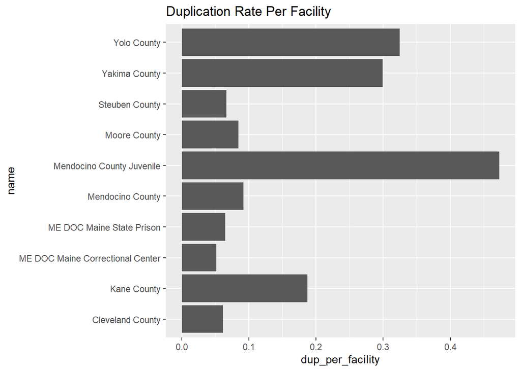

Let’s look at a user that has alot of fake birth dates, totally bogus security question answers, and more.

```
## # A tibble: 58 x 29
##        id inmate_id first_name last_name hashed_password birth_date
##     <dbl> <chr>     <chr>      <chr>     <chr>           <date>
##  1 470184 2140416   Daddy      Ortega    8d3a026cb38bf4~ 2000-02-05
##  2 472768 559       Daddy      Ortega    8d3a026cb38bf4~ 2000-05-10
##  3 473878 Papi      Daddy      Ortega    8d3a026cb38bf4~ 2001-09-08
##  4 473938 Pappy     Daddy      Ortega    8d3a026cb38bf4~ 2000-08-09
##  5 467520 214308_o~ Daddy      Ortega    8d3a026cb38bf4~ 2000-01-04
##  6 467388 00000908  Daddy      Ortega    8d3a026cb38bf4~ 2000-03-03
##  7 470208 2120416   Daddy      Ortega    8d3a026cb38bf4~ 2000-02-10
##  8 466274 22        Daddy      Ortega    8d3a026cb38bf4~ 2000-04-07
##  9 473870 Lok       Daddy      Ortega    8d3a026cb38bf4~ 2001-08-11
## 10 470461 2310804   Daddy      Ortega    8d3a026cb38bf4~ 2000-05-08
## # ... with 48 more rows, and 23 more variables: security_question_1 <chr>,
## #   security_answer_1 <chr>, security_question_2 <chr>,
## #   security_answer_2 <chr>, created_at <dttm>, updated_at <dttm>,
## #   points <dbl>, total_points <dbl>, total_spent_points <dbl>,
## #   facility_id <dbl>, status <chr>, release_date <dttm>, language <chr>,
## #   credit_balance <dbl>, balance <dbl>, desk_id <dbl>, email <chr>,
## #   phone_number <chr>, deactivation_reason <chr>, zendesk_id <chr>,
## #   state <chr>, name <chr>, goals_enabled <lgl>
```

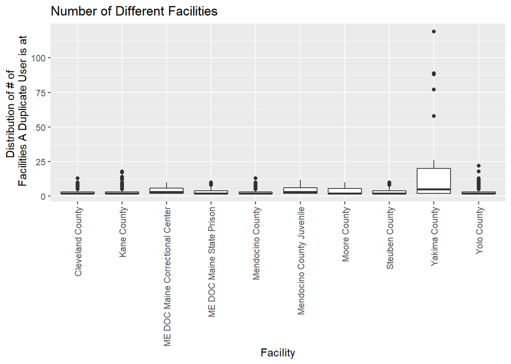

## Let’s look at sponsors

### What’s the overall deduplication rate among sponsors?

```
## # A tibble: 1 x 1
##   percent_dup
##         <dbl>
## 1       0.257
```

### For each **clear** duplicate sponsor, which IDs are they using?

```
## # A tibble: 4,934 x 3
## # Groups:   first_name [2,050]
##    first_name last_name id
##    <chr>      <chr>     <chr>
##  1 A’laysha   Hernandez 76697,76697
##  2 Aaliyah    Sanchez   65480,65480,82180
##  3 Aaron      Leyva     88065,52417
##  4 Aaron      Mascoe    90145,84330
##  5 Aaron      Newson    34349,40256,90154
##  6 Aaron      Pickett   53432,53432
##  7 Aaron      Tardiff   89840,82829
##  8 Abbagayle  Sayles    10765,10141
##  9 Abbigale   Cavin     45582,45702,45612,45703,38890,38847,45519,38807,38879,4~
## 10 Abby       Bickford  67935,71998
## # ... with 4,924 more rows
```

## Is each **clear** duplicate sponsor using different emails, phone numbers?

Yes for phone, sometimes no for emails!

```
## # A tibble: 4,934 x 3
## # Groups:   first_name [2,050]
##    first_name last_name phone_nums
##    <chr>      <chr>     <chr>
##  1 A’laysha   Hernandez alayshahernandez1@icloud.com,alayshahernandez1@icloud.c~
##  2 Aaliyah    Sanchez   aaliyahsanchez9898@gmail.com,aaliyahsanchez9898@gmail.c~
##  3 Aaron      Leyva     official.kapo630@gmail.com,aaronleyva51@gmail.com
##  4 Aaron      Mascoe    aaronryanla@gmail.com,amascoe@udel.edu
##  5 Aaron      Newson    aewn1281@sbcglobal.net,azo420c@gmail.com,azo4200c@gmail~
##  6 Aaron      Pickett   Kbgggg.4@gmail.com,Kbgggg.4@gmail.com
##  7 Aaron      Tardiff   aaron.tardiff@gmail.com,aaron.tardiff11@gmail.com
##  8 Abbagayle  Sayles    s.abbagayle@gmail.com,brookelynnclark@gmail.com
##  9 Abbigale   Cavin     cavinabbigale@gmail.com,abbigalecavin4@gmail.com,abbiga~
## 10 Abby       Bickford  abby.bickford1@gmail.com,Abhy.bickford1@gmail.com
## # ... with 4,924 more rows
```

```
## # A tibble: 4,934 x 3
## # Groups:   first_name [2,050]
##    first_name last_name phone_nums
##    <chr>      <chr>     <chr>
##  1 A’laysha   Hernandez 19105280821,19102181648
##  2 Aaliyah    Sanchez   15094159831,15092668726,18312024718
##  3 Aaron      Leyva     13312199654,13312625018
##  4 Aaron      Mascoe    19166334682,19166622919
##  5 Aaron      Newson    19165194348,12162194940,12163591165
##  6 Aaron      Pickett   19184299998,19189620707
##  7 Aaron      Tardiff   12074584898,12072422238
##  8 Abbagayle  Sayles    13098263651,13095855054
##  9 Abbigale   Cavin     14054894823,14052768435,14054451396,14053531247,1405260~
## 10 Abby       Bickford  12079495135,12076056008
## # ... with 4,924 more rows
```